# Assigment - Data Driven Decision Making

Niels Eenink

22 september, 2021

Data Driven decision making at the Tour de France.

[video not shown]

## Why was data driven decision making (3DM) useful in this business case?

A lot of sports can and will use data to improve their performance. Teams check if their sports(wo)men are performing as expected or need attention. Organisations such as the ASO (the organizing association behind the Tour de France) can also use the data to make the races more exciting to watch for the viewers.

So, not only can the ASO level-up their entertaining factor for the viewers, they can also supply cycling teams with vital information such as GPS speed, location and live video.

## How did the organization apply 3DM?

The ASO makes use of smart appliances of a company named Velon. Velon puts a little tracker on a selected number of bikes, which bikes they choose is randomly chosen.

[figure not shown]

The Velon tracker

This tracker feeds live data to the ASO so they can display it during the stages. Velon also streams the data on their websites. By doing this everyone can select their favorite cyclist and see the live data. The ASO also generates nice graphics after some races on their Twitter, as seen below.

[figure not shown]

After race graphic

## What can the organization do with 3DM that they couldn’t do before?

Teams can use data to improve their materials, for example, what tire pressure and which tire is the most suitable for a specific stage where the riders drive on a combination of tarmac and dirt?

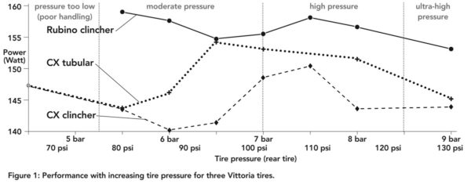

Performance with increasing tire pressure for three Vittoria tires.

Or, How can we protect our riders in crashes? Team DSM (former Team Sunweb) did this by working together with DSM and wove dyneema fabric into their cycling clothes. Using data they found the perfect amount of protection, weight and comfort for the riders.

[video not shown]

The ASO can give their viewers more insight as written before. They can also use it to determine if someone did something wrong and caused a crash. This can help to punish cyclist or to punish the RIGHT cyclist.

## References

[Velon](https://www.velon.cc/about-velon) [Tire pressure data](https://www.renehersecycles.com/tire-pressure-data-and-details/) [Dyneema](https://www.velonews.com/events/tour-de-france/team-sunweb-jerseys-feature-dyneema-for-added-protection/)